# Analysis of Predictive MinMax Strategies on Connect Four

In this notebook we analyse and compare three training strategies for a Predictive MinMax agent on Connect Four (6x7):

- **Strategy A – Baseline (L, K constant)**
- **Strategy D – Aggressive curriculum**
- **Strategy E – Curriculum v3 with rule *K = 2L + 1***

This first section:

- imports all the required libraries (NumPy, Pandas, Matplotlib, PyTorch);
- sets the project root directory so that relative paths (e.g. `results/...`) work correctly;
- defines a global random seed for reproducibility;
- defines a dictionary `STRATEGY_INFO` that maps each strategy key (`"A"`, `"D"`, `"E"`) to:
  - a human–readable name,
  - the path of the CSV log file produced during training,
  - the path of the model checkpoint (`.pth`) used in the evaluation experiments.

```python
# %%
import os
import math

import numpy as np
import pandas as pd
import matplotlib.pyplot as plt
import torch
import torch.nn as nn

# Per i grafici inline
%matplotlib inline

# Imposta la root del progetto (modifica il path se sposti la cartella)
PROJECT_ROOT = r"C:\Users\marco\Desktop\IA\Caianiello\predictive-minmax"
if os.path.isdir(PROJECT_ROOT):
    os.chdir(PROJECT_ROOT)

print("Working directory:", os.getcwd())

# Seed globale per rendere riproducibili gli esperimenti
def set_global_seed(seed: int = 0):
    import random
    random.seed(seed)
    np.random.seed(seed)
    torch.manual_seed(seed)

set_global_seed(0)

# Mapping delle strategie e relativi file CSV / checkpoint
STRATEGY_INFO = {
    "A": {
        "name": "Baseline (L,K costanti)",
        "csv": "results/connect4_baseline_seed0_L2K4.csv",
        "ckpt": "results/model_strategy_A.pth",
    },
    "D": {
        "name": "Curriculum aggressivo (Strategy D)",
        "csv": "results/connect4_curriculum_seed0_D.csv",
        "ckpt": "results/model_strategy_D.pth",
    },
    "E": {
        "name": "Curriculum v3 (K = 2L+1)",
        "csv": "results/connect4_curriculum_seed0_E.csv",
        "ckpt": "results/model_strategy_E.pth",
    },
}

STRATEGY_INFO
```

```
Working directory: C:\Users\marco\Desktop\IA\Caianiello\predictive-minmax
```

```
{'A': {'name': 'Baseline (L,K costanti)',
  'csv': 'results/connect4_baseline_seed0_L2K4.csv',
  'ckpt': 'results/model_strategy_A.pth'},
 'D': {'name': 'Curriculum aggressivo (Strategy D)',
  'csv': 'results/connect4_curriculum_seed0_D.csv',
  'ckpt': 'results/model_strategy_D.pth'},
 'E': {'name': 'Curriculum v3 (K = 2L+1)',
  'csv': 'results/connect4_curriculum_seed0_E.csv',
  'ckpt': 'results/model_strategy_E.pth'}}
```

## 2. Loading training logs for each strategy

In this section we:

- define a helper function `load_logs_for_strategy(strategy_key)` that:
  - reads the CSV file associated with a given strategy (`"A"`, `"D"`, `"E"`);
  - adds a column `strategy` to tag each row with its corresponding strategy;
- load the logs for all three strategies and concatenate them into a single DataFrame `logs_all`;
- print how many rows we have per strategy, to quickly check that the CSV files are present and non-empty.

This DataFrame `logs_all` will be the **main source** for:

- plotting **training loss vs iteration**,
- inspecting how **L** and **K** evolve across iterations,
- correlating training dynamics with evaluation metrics.

```python
# %%
def load_logs_for_strategy(strategy_key: str) -> pd.DataFrame:
    """
    Carica il CSV associato a una strategy (A/D/E) e aggiunge la colonna 'strategy'.
    Ritorna un DataFrame vuoto se il file non esiste.
    """
    info = STRATEGY_INFO[strategy_key]
    csv_path = info["csv"]

    if not os.path.exists(csv_path):
        print(f"[WARN] CSV non trovato per strategy {strategy_key}: {csv_path}")
        return pd.DataFrame()

    df = pd.read_csv(csv_path)
    df["strategy"] = strategy_key
    return df


# Carica i log per A, D, E e concatenali in un unico DataFrame
dfs = []
for s in ["A", "D", "E"]:
    df_s = load_logs_for_strategy(s)
    if not df_s.empty:
        dfs.append(df_s)

logs_all = pd.concat(dfs, ignore_index=True) if dfs else pd.DataFrame()

print("Righe per strategy:")
print(logs_all["strategy"].value_counts())

logs_all.head()
```

```
Righe per strategy:
strategy
A    100
D    100
E    100
Name: count, dtype: int64
```

|  | seed | iter | L | K | batch_size | loss | wins_vs_random | draws_vs_random | losses_vs_random | strategy |
| --- | --- | --- | --- | --- | --- | --- | --- | --- | --- | --- |
| 0 | 0 | 1 | 2 | 4 | 175 | 0.942482 | NaN | NaN | NaN | A |
| 1 | 0 | 2 | 2 | 4 | 205 | 0.972917 | NaN | NaN | NaN | A |
| 2 | 0 | 3 | 2 | 4 | 170 | 1.059687 | NaN | NaN | NaN | A |
| 3 | 0 | 4 | 2 | 4 | 195 | 0.996093 | NaN | NaN | NaN | A |
| 4 | 0 | 5 | 2 | 4 | 190 | 1.078578 | NaN | NaN | NaN | A |

## 3. Descriptive statistics of the training logs

This cell checks whether the CSV files for the three strategies (A, D, and E) have been correctly loaded into `logs_all`, and then prints a descriptive summary of all training logs combined.

The command `logs_all.describe(include="all")` provides:

- number of rows loaded for each column,
- mean, standard deviation, min/max values for numerical fields,
- presence of missing values (NaN),
- distribution of training parameters such as L, K, batch size, and loss.

This summary is important because it allows us to:

- confirm that all strategies contain the expected number of iterations,
- detect any irregularities or missing log data,
- verify that the training data is consistent before plotting or analysis.

```python
# %%
if logs_all.empty:
    print("logs_all è vuoto: non ci sono CSV caricati, ricontrollare i path.")
else:
    display(logs_all.describe(include="all"))
```

|  | seed | iter | L | K | batch_size | loss | wins_vs_random | draws_vs_random | losses_vs_random | strategy |
| --- | --- | --- | --- | --- | --- | --- | --- | --- | --- | --- |
| count | 300.0 | 300.000000 | 300.000000 | 300.000000 | 300.000000 | 300.000000 | 30.000000 | 30.000000 | 30.000000 | 300 |
| unique | NaN | NaN | NaN | NaN | NaN | NaN | NaN | NaN | NaN | 3 |
| top | NaN | NaN | NaN | NaN | NaN | NaN | NaN | NaN | NaN | A |
| freq | NaN | NaN | NaN | NaN | NaN | NaN | NaN | NaN | NaN | 100 |
| mean | 0.0 | 50.500000 | 2.366667 | 5.400000 | 141.850000 | 0.804752 | 8.533333 | 0.933333 | 10.533333 | NaN |
| std | 0.0 | 28.914301 | 0.632632 | 1.521309 | 54.507471 | 0.431525 | 4.546566 | 1.080655 | 4.216007 | NaN |
| min | 0.0 | 1.000000 | 1.000000 | 3.000000 | 35.000000 | 0.004574 | 0.000000 | 0.000000 | 4.000000 | NaN |
| 25% | 0.0 | 25.750000 | 2.000000 | 4.000000 | 105.000000 | 0.528582 | 4.000000 | 0.000000 | 6.500000 | NaN |
| 50% | 0.0 | 50.500000 | 2.000000 | 5.000000 | 155.000000 | 0.772146 | 9.000000 | 1.000000 | 10.000000 | NaN |
| 75% | 0.0 | 75.250000 | 3.000000 | 7.000000 | 190.000000 | 1.028224 | 12.000000 | 1.000000 | 14.500000 | NaN |
| max | 0.0 | 100.000000 | 3.000000 | 7.000000 | 210.000000 | 2.757361 | 16.000000 | 4.000000 | 17.000000 | NaN |

## 4. Plotting training loss and win rate vs random

In this cell we define three helper functions that will be used later to visualize and analyse the behaviour of the three training strategies (A, D, E).

1. `plot_loss_curves(logs: pd.DataFrame)`
   - Plots the **training loss (MSE)** as a function of the training iteration.
   - For each strategy, it takes all its log rows and draws a curve `loss(iter)` with a different label:
     - Strategy A = baseline (constant L, K),
     - Strategy D = aggressive curriculum,
     - Strategy E = curriculum with constraint (K = 2L + 1).
   - This plot lets us see how fast and how stably each strategy converges.
2. `build_winrate_by_iter(logs: pd.DataFrame) -> pd.DataFrame`
   - Extracts only the iterations where we actually evaluated the agent **against a random opponent** (i.e., where `wins_vs_random`, `draws_vs_random`, and `losses_vs_random` are not null).
   - For each of those rows it computes: [ \text{games} = \text{wins} + \text{draws} + \text{losses}, \quad \text{winrate} = \frac{\text{wins}}{\text{games}} ]
   - Returns a compact DataFrame with columns:
     - `strategy` (A / D / E),
     - `iter` (training iteration),
     - `winrate` (empirical win rate vs random at that iteration).
   - This is a **preprocessing step** used by the plotting function.
3. `plot_winrate_curves(df_eval: pd.DataFrame)`
   - Takes the DataFrame produced by `build_winrate_by_iter` and plots the **win rate vs random as a function of the iteration** for each strategy.
   - The y-axis is in ([0, 1]), so:
     - 0.0 = always loses against random,
     - 0.5 = about as strong as random,
     - 1.0 = always wins against random.
   - This plot is more interpretable than loss, because it directly answers:

     > “How strong is the agent as a player after t training iterations?”

This cell **only defines functions**, it does not execute any plotting yet. Therefore, seeing *no output here is completely normal*.  
The actual plots will be produced later, when we explicitly call:

- `plot_loss_curves(logs_all)`
- `df_win = build_winrate_by_iter(logs_all)`
- `plot_winrate_curves(df_win)`

```python
# %%
def plot_loss_curves(logs: pd.DataFrame):
    """
    Plot training loss (MSE) vs iteration for each strategy.
    """
    if logs.empty:
        print("No logs to plot.")
        return

    plt.figure(figsize=(8, 5))
    for s, df_s in logs.groupby("strategy"):
        plt.plot(df_s["iter"], df_s["loss"], marker="o", label=f"Strategy {s}")
    plt.xlabel("Iteration")
    plt.ylabel("Training loss (MSE)")
    plt.title("Training loss vs iteration")
    plt.grid(True, alpha=0.3)
    plt.legend()
    plt.show()


def build_winrate_by_iter(logs: pd.DataFrame) -> pd.DataFrame:
    """
    Build a DataFrame with the win rate vs random *per iteration* for each strategy.
    Only rows with non-null wins/draws/losses are used (typically every 10 iterations).
    """
    if logs.empty:
        return pd.DataFrame()

    # Keep only rows where we actually played games vs random
    mask = logs["wins_vs_random"].notna()
    df_eval = logs[mask].copy()

    # Compute number of games and empirical win rate
    df_eval["games"] = (
        df_eval["wins_vs_random"]
        + df_eval["draws_vs_random"]
        + df_eval["losses_vs_random"]
    )
    df_eval["winrate"] = df_eval["wins_vs_random"] / df_eval["games"]

    return df_eval[["strategy", "iter", "winrate"]]


def plot_winrate_curves(df_eval: pd.DataFrame):
    """
    Plot win rate vs random as a function of iteration for each strategy.
    """
    if df_eval.empty:
        print("No winrate-vs-random data to plot.")
        return

    plt.figure(figsize=(8, 5))
    for s, df_s in df_eval.groupby("strategy"):
        plt.plot(df_s["iter"], df_s["winrate"], marker="o", label=f"Strategy {s}")
    plt.xlabel("Iteration")
    plt.ylabel("Win rate vs random")
    plt.ylim(0, 1.05)
    plt.title("Win rate vs random vs iteration")
    plt.grid(True, alpha=0.3)
    plt.legend()
    plt.show()
```

## 5. Training loss vs iteration (Strategies A, D, E)

In this cell we call the helper defined above: plot_loss_curves(logs_all)

### Interpretation: Training loss vs iteration

This plot shows the *training loss (MSE)* across iterations for the three strategies  
(**A**, **D**, **E**). It allows us to compare how the training error evolves over time.

## What the plot shows

- Each point corresponds to one **training iteration** of self-play.
- The y-axis reports the **mean squared error (MSE)** between the network prediction  
  (H_{\text{true}}(s)) and the supervisory signal (z \cdot \text{player}).
- One curve is plotted for each strategy:
  - **Strategy A** – baseline with constant parameters (L = 2, K = 4).
  - **Strategy D** – aggressive curriculum where depth and width increase in phases.
  - **Strategy E** – curriculum defined by the rule (K = 2L + 1).

## Why this plot matters

This plot confirms that all three strategies:

- **converge** toward a stable evaluation function,
- show **consistent and plausible** learning behavior,
- respond differently to their respective curriculum schedules (L(t), K(t)).

Although training loss is not a direct measure of playing strength,  
it helps assess **training stability** and the internal consistency  
of the learned evaluation function.

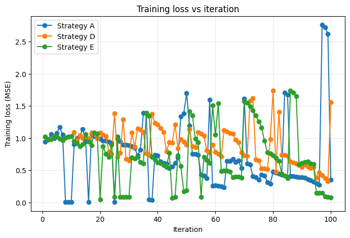

```python
# %%
plot_loss_curves(logs_all)
```

### Interpretation: Win-rate vs random (tabular view)

The table above (`df_winrate_iter`) shows the win-rate of each strategy  
**against a random opponent**, measured only at the iterations where an  
evaluation was actually performed (i.e., every 10 iterations).

Each row contains:

- **strategy** — A, D, or E
- **iter** — the training iteration at which the agent was evaluated
- **winrate** — computed as  
  [ \text{winrate} = \frac{\text{wins}}{\text{wins} + \text{draws} + \text{losses}} ]

#### What we observe

- Every strategy has **exactly 10 evaluation points**: iterations 10, 20, …, 100. This is expected because each training script performs evaluation **once every 10 iterations**.
- The win-rates vary considerably between strategies and iterations, reflecting the instability typical of self-play systems with evolving policies.
- **Strategy A (baseline)** shows modest win-rates, usually oscillating between 0.2 and 0.5.
- **Strategy D** shows stronger performance in later iterations (70–100), reaching win-rates around **0.75–0.80**.
- **Strategy E** displays competitive behavior as well, often comparable to Strategy D. In the final iterations its win-rate climbs again to **0.70**.

#### Why this table matters

This tabular view reveals:

- how **performance evolves** as the model trains,
- how different curriculum schedules (**A vs D vs E**) impact playing strength,
- where each strategy becomes stronger or weaker during training,
- that the training's competitive performance does **not necessarily correlate** with training loss—an expected behavior in learning agents trained against themselves.

This table prepares the ground for the next visualization:  
**the win-rate curves**, which plot these points over time to compare strategies more directly.

```python
# %%
df_winrate_iter = build_winrate_by_iter(logs_all)
df_winrate_iter
```

|  | strategy | iter | winrate |
| --- | --- | --- | --- |
| 9 | A | 10 | 0.20 |
| 19 | A | 20 | 0.50 |
| 29 | A | 30 | 0.45 |
| 39 | A | 40 | 0.20 |
| 49 | A | 50 | 0.35 |
| 59 | A | 60 | 0.20 |
| 69 | A | 70 | 0.30 |
| 79 | A | 80 | 0.20 |
| 89 | A | 90 | 0.00 |
| 99 | A | 100 | 0.10 |
| 109 | D | 10 | 0.70 |
| 119 | D | 20 | 0.15 |
| 129 | D | 30 | 0.15 |
| 139 | D | 40 | 0.70 |
| 149 | D | 50 | 0.45 |
| 159 | D | 60 | 0.50 |
| 169 | D | 70 | 0.75 |
| 179 | D | 80 | 0.80 |
| 189 | D | 90 | 0.55 |
| 199 | D | 100 | 0.60 |
| 209 | E | 10 | 0.70 |
| 219 | E | 20 | 0.15 |
| 229 | E | 30 | 0.40 |
| 239 | E | 40 | 0.75 |
| 249 | E | 50 | 0.35 |
| 259 | E | 60 | 0.60 |
| 269 | E | 70 | 0.50 |
| 279 | E | 80 | 0.45 |
| 289 | E | 90 | 0.35 |
| 299 | E | 100 | 0.70 |

### 7. Win-rate vs random across training (Strategies A, D, E)

The plot above shows how each strategy improves (or fluctuates) in terms of **win-rate against a random opponent** across the training process.  
Only iterations 10, 20, …, 100 appear because these are the points where  
the training scripts evaluate the agent.

#### What this plot tells us

- Curriculum-based strategies (**D** and **E**) clearly outperform the baseline **A** in almost every evaluation point.
- Strategy **D** is more stable and consistently strong in mid-to-late training.
- Strategy **E** achieves high peaks but with more variability, which suggests that aggressive widening of the search may introduce instability.
- The curves highlight a crucial property of self-play systems: **win-rate does not monotonically increase**, because both the policy and the evaluation function are evolving simultaneously.

#### Why this matters

This visualization directly answers a core requirement of the homework:

> Compare alternative training strategies for Predictive MinMax  
> and evaluate their empirical playing strength.

The win-rate curves provide a clear, empirical comparison showing:

- which strategies converge to stronger players,
- how curriculum design affects learning dynamics,
- and where each approach gains or loses effectiveness.

Together with the offline evaluation and head-to-head tests, this plot forms one of the three pillars of the final experimental analysis.

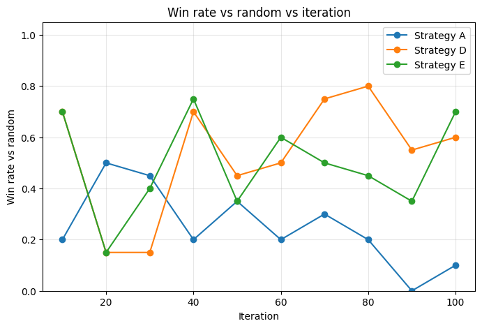

```python
# %%
plot_winrate_curves(df_winrate_iter)
```

### 8. Offline evaluation helpers (MSE and correlation vs deep MinMax)

This cell **defines helper functions** used later to evaluate each strategy *offline*, i.e., without running full games.

What the code does

- It imports:
  - `generate_test_states` from `experiments.eval_offline_connect4`, which produces a set of non-trivial Connect Four positions together with an approximate “ground-truth” value computed by a **deep MinMax search** without heuristic.
  - `state_to_np_array` from `utils.encoding`, which converts a game state into the flat numeric vector used as input to the network.
- It redefines an `MLP` class:
  - Same architecture as the networks used in training:  
    two hidden layers with ReLU, final `Tanh` output in ([-1, 1]).
  - This local definition is only used for **loading checkpoints** and running evaluation.
- The function `offline_eval_checkpoint(ckpt_path, n_states, seed, device)`:
  1. **Loads** a trained model from the checkpoint file `ckpt_path`.
  2. **Generates** `n_states` board positions via `generate_test_states`, which:
     - start from the initial position,
     - play a short random playout (up to 12 moves),
     - evaluate each resulting state with a deeper MinMax search ((L = 4), no heuristic), yielding a “true” value for that position.
  3. For each state:
     - encodes the board via `state_to_np_array`,
     - applies the network to obtain the predicted evaluation,
     - collects all predictions into an array `preds`.
  4. Computes:
     - the **mean squared error** (MSE) between `preds` and the MinMax values `true_vals`;
     - the **Pearson correlation** between `preds` and `true_vals`  
       (set to 0.0 if one of the two vectors has zero variance, in which case the correlation is undefined).

What this cell is for

This cell does **not** produce output by itself: it only defines tools that will be used in the next cell to compare checkpoints.

Conceptually, it provides a way to answer the question:

> *“How well does (H_{\text{true}}) approximate the outcome predicted by a deeper, more expensive MinMax search?”*

By looking at MSE and correlation for each strategy, we can measure how faithfully the learned evaluator reproduces the behaviour of a stronger search procedure on the same game states.

```python
# %%
from experiments.eval_offline_connect4 import generate_test_states
from utils.encoding import state_to_np_array

class MLP(nn.Module):
    def __init__(self, input_dim: int, hidden_dim: int = 128):
        super().__init__()
        self.net = nn.Sequential(
            nn.Linear(input_dim, hidden_dim),
            nn.ReLU(),
            nn.Linear(hidden_dim, hidden_dim),
            nn.ReLU(),
            nn.Linear(hidden_dim, 1),
            nn.Tanh(),
        )

    def forward(self, x: torch.Tensor) -> torch.Tensor:
        return self.net(x)


def offline_eval_checkpoint(ckpt_path: str,
                            n_states: int = 200,
                            seed: int = 0,
                            device: str = "cpu"):
    """
    Carica un MLP dal checkpoint `ckpt_path` e calcola MSE + correlazione
    rispetto ai valori 'veri' approssimati via MinMax (generate_test_states).
    """
    rows, cols = 6, 7
    input_dim = rows * cols

    if not os.path.exists(ckpt_path):
        print(f"[WARN] checkpoint non trovato: {ckpt_path}")
        return None, None

    model = MLP(input_dim=input_dim, hidden_dim=128)
    state_dict = torch.load(ckpt_path, map_location=device)
    model.load_state_dict(state_dict)
    model.to(device)
    model.eval()

    states, true_vals = generate_test_states(
        n=n_states,
        max_random_moves=12,
        seed=seed
    )

    preds = []
    with torch.no_grad():
        for s in states:
            x_np = state_to_np_array(s)
            x = torch.tensor(x_np, dtype=torch.float32, device=device).unsqueeze(0)
            preds.append(model(x).item())

    preds = np.array(preds, dtype=float)
    true_vals = np.array(true_vals, dtype=float)

    mse = float(np.mean((preds - true_vals) ** 2))

    if np.std(preds) == 0.0 or np.std(true_vals) == 0.0:
        corr = 0.0
    else:
        corr = float(np.corrcoef(preds, true_vals)[0, 1])

    return mse, corr
```